# Josh Barlow

### Sports analytics with advanced regression

```python
import pandas as pd
import numpy as np
import seaborn as sns
import matplotlib.pyplot as plt
%matplotlib inline

#regression packages
import sklearn.linear_model as lm
from sklearn.metrics import mean_squared_error
from sklearn.metrics import explained_variance_score
import statsmodels.formula.api as sm

#lasso regression
from sklearn import linear_model

#f_regression (feature selection)
from sklearn.feature_selection import f_regression
from sklearn.feature_selection import SelectKBest

# recursive feature selection (feature selection)
from sklearn.feature_selection import RFE
```

```python
data = pd.read_csv("data/NFLData.csv")
data.head()
```

|  | Overall | Off_Rank | Team | Games | Points | Yards | Off_Plays | Fum_Lost | Fdowns | Pass_Comp | ... | Pass_TD_Allowed | Interceptions | Def_Pass_NYPA | Pass_1stD_Allowed | Rush_Yds_Allowed | Rush_TD_Allowed | Def_Rush_YPA | Rush_1stD_Allowed | Def_Pen | Def_Pen_Yds |
| --- | --- | --- | --- | --- | --- | --- | --- | --- | --- | --- | --- | --- | --- | --- | --- | --- | --- | --- | --- | --- | --- |
| 0 | 3 | 1 | San Francisco 49ers | 14 | 352 | 4503 | 862 | 15 | 237 | 226 | ... | 19 | 22 | 5.2 | 110 | 1799 | 12 | 4.2 | 81 | 87 | 965 |
| 1 | 6 | 3 | Minnesota Vikings | 14 | 335 | 3815 | 881 | 16 | 225 | 173 | ... | 6 | 28 | 3.5 | 89 | 1365 | 4 | 3.4 | 68 | 58 | 586 |
| 2 | 5 | 2 | Detroit Lions | 14 | 347 | 3984 | 844 | 15 | 243 | 167 | ... | 14 | 28 | 5.8 | 112 | 1152 | 7 | 3.2 | 61 | 90 | 805 |
| 3 | 11 | 5 | Los Angeles Rams | 14 | 325 | 4271 | 879 | 17 | 224 | 218 | ... | 15 | 19 | 5.1 | 113 | 1359 | 6 | 3.4 | 64 | 77 | 825 |
| 4 | 9 | 4 | St. Louis Cardinals | 14 | 325 | 4471 | 845 | 14 | 226 | 178 | ... | 16 | 21 | 5.0 | 116 | 1762 | 10 | 3.7 | 96 | 68 | 659 |

5 rows × 40 columns

Below is an explanation of the teams DataFrame attribtues:

- Note: Data used was regular season data between 1970-2015. All variables are season statistics. The models are designed to be able to enter the regular season data and predict the team rankings for that season.

Overall: Team rank at end of season  
Off_Rank: Team Offensive rank  
Team: Team name  
Games: Number of games played  
Points: Total points scored  
Yards: Total yards accumulated  
Off_Plays: Total offensive plays executed  
Fum_Lost: Total offensive fumbles lost  
Fdowns: Total first downs  
Pass_Comp: Total completed passes  
Pass_Att: Total attempted passes  
Pass_Yds: Total passing yards  
Pass_TD: Total passing touchdowns  
Pass_Int: Total interceptions thrown  
Pass_NYPA: Net yards per passing attempt  
Pass_1stD: Total passing firstdowns  
Rush_Att: Total rushing attempts  
Rush_Yds: Total rushing yards  
Rush_TD: Total rushing touchdowns  
Rush_YPA: Average rushing yards per attemps  
Rush_1stD: Total rushing firstdowns  
Off_Pen: Total offensive penalties  
Off_Pen_Yds: Total offensive penalty yards  
Def_Rank: Team Defensive rank  
Opp_Points: Total opponent points allowed  
Yds_Allowed: Total opponent yards allowed  
Def_YPP: Opponent average yards per play  
Takeaways: Total takeaways  
Fdowns_Allowed: Opponent firstdowns allowed  
Pass_Yds_Allowed: Opponent passing yards allowed  
Pass_TD_Allowed: Opponent passing touchdowns allowed  
Interceptions: Total interceptions  
Def_Pass_NYPA: Opponent net yards per passing attempt allowed  
Pass_1stD_Allowed: Opponent passing firstdowns allowed  
Rush_Yds_Allowed: Opponent rushing yards allowed  
Rush_TD_Allowed: Opponent rushing touchdowns allowed  
Def_Rush_YPA: Opponent average rushing yards per attempt allowed  
Rush_1stD_Allowed: Opponent rushing firstdowns allowed  
Def_Pen: Total defensive penalties  
Def_Pen_Yds: Total defensive penalty yards

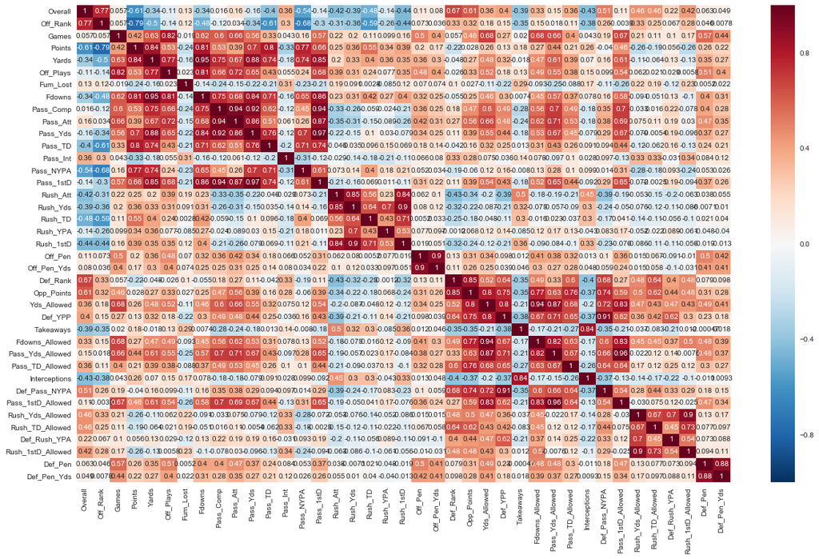

```python
# correlation heatmap provides visual representation of the relationships of all variables
plt.figure(figsize=(20,12))
sns.heatmap(data.corr(), annot=True)
```

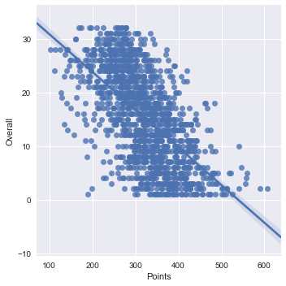

```python
sns.lmplot('Points', 'Overall', data)
```

```python
data = data.drop(['Team', 'Games'], axis=1)
data.head(2)
```

|  | Overall | Off_Rank | Points | Yards | Off_Plays | Fum_Lost | Fdowns | Pass_Comp | Pass_Att | Pass_Yds | ... | Pass_TD_Allowed | Interceptions | Def_Pass_NYPA | Pass_1stD_Allowed | Rush_Yds_Allowed | Rush_TD_Allowed | Def_Rush_YPA | Rush_1stD_Allowed | Def_Pen | Def_Pen_Yds |
| --- | --- | --- | --- | --- | --- | --- | --- | --- | --- | --- | --- | --- | --- | --- | --- | --- | --- | --- | --- | --- | --- |
| 0 | 3 | 1 | 352 | 4503 | 862 | 15 | 237 | 226 | 383 | 2923 | ... | 19 | 22 | 5.2 | 110 | 1799 | 12 | 4.2 | 81 | 87 | 965 |
| 1 | 6 | 3 | 335 | 3815 | 881 | 16 | 225 | 173 | 344 | 2181 | ... | 6 | 28 | 3.5 | 89 | 1365 | 4 | 3.4 | 68 | 58 | 586 |

2 rows × 38 columns

```python
#assigning columns to X and Y variables; currently all x-variables available are being used
y = data['Overall']
X = data.drop(['Overall'], axis =1)
```

```python
model1 = lm.LinearRegression()
model1.fit(X, y)
model1_y = model1.predict(X)
```

```python
print 'Coefficients: ', model1.coef_
print "y-intercept ", model1.intercept_
```

```
Coefficients:  [  4.24885787e-01  -1.34609183e-02   2.26670420e+10   1.65380033e-02
  -1.78837772e-02  -6.19995458e-03   2.12748647e-03  -1.12194264e-03
  -2.26670420e+10   1.59860849e-02   1.38831139e-02   1.19506955e-01
  -6.55055046e-03  -2.34680176e-02  -2.26670420e+10   4.91703749e-02
   8.90790634e-01  -1.33006573e-02  -1.62386894e-03   8.98361206e-04
   2.26085186e-01   3.26766968e-02  -3.89978868e+10   3.75817301e+00
  -4.05921936e-02  -9.78136063e-03   3.89978868e+10  -2.92332768e-02
   5.25541306e-02   1.60857275e-01   1.73403621e-02   3.89978868e+10
  -9.70124006e-02  -3.62368434e+00   1.15859509e-02   2.09187269e-02
  -2.09236145e-03]
y-intercept  -4.94188844574
```

```python
pd.DataFrame(zip(X.columns, np.transpose(model1.coef_)))
```

|  | 0 | 1 |
| --- | --- | --- |
| 0 | Off_Rank | 4.248858e-01 |
| 1 | Points | -1.346092e-02 |
| 2 | Yards | 2.266704e+10 |
| 3 | Off_Plays | 1.653800e-02 |
| 4 | Fum_Lost | -1.788378e-02 |
| 5 | Fdowns | -6.199955e-03 |
| 6 | Pass_Comp | 2.127486e-03 |
| 7 | Pass_Att | -1.121943e-03 |
| 8 | Pass_Yds | -2.266704e+10 |
| 9 | Pass_TD | 1.598608e-02 |
| 10 | Pass_Int | 1.388311e-02 |
| 11 | Pass_NYPA | 1.195070e-01 |
| 12 | Pass_1stD | -6.550550e-03 |
| 13 | Rush_Att | -2.346802e-02 |
| 14 | Rush_Yds | -2.266704e+10 |
| 15 | Rush_TD | 4.917037e-02 |
| 16 | Rush_YPA | 8.907906e-01 |
| 17 | Rush_1stD | -1.330066e-02 |
| 18 | Off_Pen | -1.623869e-03 |
| 19 | Off_Pen_Yds | 8.983612e-04 |
| 20 | Def_Rank | 2.260852e-01 |
| 21 | Opp_Points | 3.267670e-02 |
| 22 | Yds_Allowed | -3.899789e+10 |
| 23 | Def_YPP | 3.758173e+00 |
| 24 | Takeaways | -4.059219e-02 |
| 25 | Fdowns_Allowed | -9.781361e-03 |
| 26 | Pass_Yds_Allowed | 3.899789e+10 |
| 27 | Pass_TD_Allowed | -2.923328e-02 |
| 28 | Interceptions | 5.255413e-02 |
| 29 | Def_Pass_NYPA | 1.608573e-01 |
| 30 | Pass_1stD_Allowed | 1.734036e-02 |
| 31 | Rush_Yds_Allowed | 3.899789e+10 |
| 32 | Rush_TD_Allowed | -9.701240e-02 |
| 33 | Def_Rush_YPA | -3.623684e+00 |
| 34 | Rush_1stD_Allowed | 1.158595e-02 |
| 35 | Def_Pen | 2.091873e-02 |
| 36 | Def_Pen_Yds | -2.092361e-03 |

```python
coef = ["%.3f" % i for i in model1.coef_]
xcolumns = [ i for i in X.columns ]
zip(xcolumns, coef)
```

```
[('Off_Rank', '0.425'),
 ('Points', '-0.013'),
 ('Yards', '22667042041.389'),
 ('Off_Plays', '0.017'),
 ('Fum_Lost', '-0.018'),
 ('Fdowns', '-0.006'),
 ('Pass_Comp', '0.002'),
 ('Pass_Att', '-0.001'),
 ('Pass_Yds', '-22667042041.390'),
 ('Pass_TD', '0.016'),
 ('Pass_Int', '0.014'),
 ('Pass_NYPA', '0.120'),
 ('Pass_1stD', '-0.007'),
 ('Rush_Att', '-0.023'),
 ('Rush_Yds', '-22667042041.389'),
 ('Rush_TD', '0.049'),
 ('Rush_YPA', '0.891'),
 ('Rush_1stD', '-0.013'),
 ('Off_Pen', '-0.002'),
 ('Off_Pen_Yds', '0.001'),
 ('Def_Rank', '0.226'),
 ('Opp_Points', '0.033'),
 ('Yds_Allowed', '-38997886811.972'),
 ('Def_YPP', '3.758'),
 ('Takeaways', '-0.041'),
 ('Fdowns_Allowed', '-0.010'),
 ('Pass_Yds_Allowed', '38997886811.969'),
 ('Pass_TD_Allowed', '-0.029'),
 ('Interceptions', '0.053'),
 ('Def_Pass_NYPA', '0.161'),
 ('Pass_1stD_Allowed', '0.017'),
 ('Rush_Yds_Allowed', '38997886811.975'),
 ('Rush_TD_Allowed', '-0.097'),
 ('Def_Rush_YPA', '-3.624'),
 ('Rush_1stD_Allowed', '0.012'),
 ('Def_Pen', '0.021'),
 ('Def_Pen_Yds', '-0.002')]
```

```python
# print mean square error and r-squared
print "mean square error: ", mean_squared_error(y, model1_y)
print "variance or r-squared: ", explained_variance_score(y, model1_y)
```

```
mean square error:  14.3271594606
variance or r-squared:  0.806028696528
```

```python
# load the 2016 regular season data
rank = pd.read_csv("data/2016.csv")
rank = pd.DataFrame(rank)

# Use model1 to predict y value; we are still using all available X-variables for this test
columns = rank[['Off_Rank', 'Points', 'Yards', 'Off_Plays', 'Fum_Lost', 'Fdowns', 'Pass_Comp', 'Pass_Att',
                'Pass_Yds', 'Pass_TD', 'Pass_Int', 'Pass_NYPA', 'Pass_1stD', 'Rush_Att', 'Rush_Yds', 'Rush_TD',
                'Rush_YPA', 'Rush_1stD', 'Off_Pen', 'Off_Pen_Yds', 'Def_Rank', 'Opp_Points', 'Yds_Allowed',
                'Def_YPP', 'Takeaways', 'Fdowns_Allowed', 'Pass_Yds_Allowed', 'Pass_TD_Allowed', 'Interceptions',
                'Def_Pass_NYPA', 'Pass_1stD_Allowed', 'Rush_Yds_Allowed', 'Rush_TD_Allowed', 'Def_Rush_YPA',
                'Rush_1stD_Allowed', 'Def_Pen', 'Def_Pen_Yds']]
predict = pd.DataFrame(model1.predict(columns))
predict = predict.rename(columns={0: 'Predicted Overall'})

# put the Team and Predicted Overall ranking in a table together and ensure the columns are labeled correctly
predict = pd.DataFrame(zip(rank['Team'], predict['Predicted Overall']))
predict = predict.rename(columns={0: 'Team', 1: 'Predicted Overall'})
predict.head()
```

|  | Team | Predicted Overall |
| --- | --- | --- |
| 0 | Atlanta Falcons | 7.652555 |
| 1 | New England Patriots | 0.676613 |
| 2 | New Orleans Saints | 14.728644 |
| 3 | New York Giants | 14.899160 |
| 4 | Seattle Seahawks | 12.274910 |

```python
# We are using 2016 regular season stats to predict the Super Bowl winner for that season
actual = pd.read_csv("data/2016Actual.csv")
actual.head()
```

|  | Actual Finish | Team |
| --- | --- | --- |
| 0 | 2 | Atlanta Falcons |
| 1 | 1 | New England Patriots |
| 2 | 21 | New Orleans Saints |
| 3 | 10 | New York Giants |
| 4 | 7 | Seattle Seahawks |

```python
# Create a new column named "Predicted Rank". This creates a column listing 1 to 32 due to the predicted rankings
# lack of whole number structure
#predict['Predicted Rank'] = 0

# Sort the predict chart by "Predicted overall". This ranks the teams by predicted regular season finish.
predict = predict.sort_values(by=["Predicted Overall"], ascending=[True])

# Create a new column named "Predicted Rank". This creates a column listing 1 to 32 due to the predicted rankings
# lack of whole number structure
#predict = predict.reset_index()
predict['Predicted Rank'] = predict.index+1

# Delete the index column that the above code creates
del predict['index']

predict
```

[output not shown]

```python
predict = pd.merge(predict, actual, on='Team')

# create a new column that contains the percentage change from week 1 to week 2
predict['Difference']= (predict['Predicted Rank'] - predict['Actual Finish'])
predict['% Difference']= (((predict['Predicted Rank'] - predict['Actual Finish']) / predict['Predicted Rank']) * 100)

# clean up the % Change column so it is more appealing, eliminating the decimals
predict['% Difference'] = predict['% Difference'].astype(int)
predict['% Difference'] = predict['% Difference'].abs()

# calculate MSE
mse = 0
count = 0
for i in predict['Difference']:
    count += 1
    mse += (i*i)
model1_mse = float(mse) / float(count)

count = 0
for i in predict['Difference']:
    if i == 0:
        count+=1

a = 0
for i in predict['Difference']:
    a+=1
    if a == 1:
        if i == 0:
            print("THE MODEL CORRECTLY PREDICTED THE SUPERBOWL WINNER!!!")

print '%s %s' %("Number of rankings correctly predicted: ", count)
print '%s %s' %("Model1 Mean Square Error: ", "%.3f" % model1_mse)
predict
```

```
THE MODEL CORRECTLY PREDICTED THE SUPERBOWL WINNER!!!
Number of rankings correctly predicted:  7
Model1 Mean Square Error:  37.375
```

|  | Team | Predicted Overall | Predicted Rank | Actual Finish | Difference | % Difference |
| --- | --- | --- | --- | --- | --- | --- |
| 0 | New England Patriots | 0.676613 | 1 | 1 | 0 | 0 |
| 1 | Dallas Cowboys | 4.483633 | 2 | 5 | -3 | 150 |
| 2 | Atlanta Falcons | 7.652555 | 3 | 2 | 1 | 33 |
| 3 | Pittsburgh Steelers | 9.531604 | 4 | 3 | 1 | 25 |
| 4 | Kansas City Chiefs | 10.500573 | 5 | 6 | -1 | 20 |
| 5 | Arizona Cardinals | 11.533416 | 6 | 20 | -14 | 233 |
| 6 | Seattle Seahawks | 12.274910 | 7 | 7 | 0 | 0 |
| 7 | Green Bay Packers | 13.256531 | 8 | 4 | 4 | 50 |
| 8 | Oakland Raiders | 13.371704 | 9 | 9 | 0 | 0 |
| 9 | Indianapolis Colts | 13.403928 | 10 | 17 | -7 | 70 |
| 10 | Denver Broncos | 13.655261 | 11 | 15 | -4 | 36 |
| 11 | Washington Redskins | 14.122552 | 12 | 16 | -4 | 33 |
| 12 | Tennessee Titans | 14.387505 | 13 | 13 | 0 | 0 |
| 13 | New Orleans Saints | 14.728644 | 14 | 21 | -7 | 50 |
| 14 | Philadelphia Eagles | 14.820873 | 15 | 23 | -8 | 53 |
| 15 | New York Giants | 14.899160 | 16 | 10 | 6 | 37 |
| 16 | Minnesota Vikings | 14.990134 | 17 | 19 | -2 | 11 |
| 17 | Cincinnati Bengals | 15.227890 | 18 | 24 | -6 | 33 |
| 18 | Buffalo Bills | 15.292370 | 19 | 22 | -3 | 15 |
| 19 | Tampa Bay Buccaneers | 16.604777 | 20 | 14 | 6 | 30 |
| 20 | San Diego Chargers | 16.635371 | 21 | 26 | -5 | 23 |
| 21 | Miami Dolphins | 16.932908 | 22 | 11 | 11 | 50 |
| 22 | Baltimore Ravens | 17.238138 | 23 | 18 | 5 | 21 |
| 23 | Detroit Lions | 17.925973 | 24 | 12 | 12 | 50 |
| 24 | Carolina Panthers | 18.729280 | 25 | 25 | 0 | 0 |
| 25 | Houston Texans | 21.443650 | 26 | 8 | 18 | 69 |
| 26 | Jacksonville Jaguars | 24.908126 | 27 | 29 | -2 | 7 |
| 27 | Chicago Bears | 25.287741 | 28 | 30 | -2 | 7 |
| 28 | Los Angeles Rams | 27.845478 | 29 | 28 | 1 | 3 |
| 29 | New York Jets | 29.015593 | 30 | 27 | 3 | 10 |
| 30 | San Francisco 49ers | 29.205664 | 31 | 31 | 0 | 0 |
| 31 | Cleveland Browns | 32.649492 | 32 | 32 | 0 | 0 |

# Lasso using all X-Variables

```python
data2 = pd.read_csv("data/NFLData.csv")
data2.head()
```

|  | Overall | Off_Rank | Team | Games | Points | Yards | Off_Plays | Fum_Lost | Fdowns | Pass_Comp | ... | Pass_TD_Allowed | Interceptions | Def_Pass_NYPA | Pass_1stD_Allowed | Rush_Yds_Allowed | Rush_TD_Allowed | Def_Rush_YPA | Rush_1stD_Allowed | Def_Pen | Def_Pen_Yds |
| --- | --- | --- | --- | --- | --- | --- | --- | --- | --- | --- | --- | --- | --- | --- | --- | --- | --- | --- | --- | --- | --- |
| 0 | 3 | 1 | San Francisco 49ers | 14 | 352 | 4503 | 862 | 15 | 237 | 226 | ... | 19 | 22 | 5.2 | 110 | 1799 | 12 | 4.2 | 81 | 87 | 965 |
| 1 | 6 | 3 | Minnesota Vikings | 14 | 335 | 3815 | 881 | 16 | 225 | 173 | ... | 6 | 28 | 3.5 | 89 | 1365 | 4 | 3.4 | 68 | 58 | 586 |
| 2 | 5 | 2 | Detroit Lions | 14 | 347 | 3984 | 844 | 15 | 243 | 167 | ... | 14 | 28 | 5.8 | 112 | 1152 | 7 | 3.2 | 61 | 90 | 805 |
| 3 | 11 | 5 | Los Angeles Rams | 14 | 325 | 4271 | 879 | 17 | 224 | 218 | ... | 15 | 19 | 5.1 | 113 | 1359 | 6 | 3.4 | 64 | 77 | 825 |
| 4 | 9 | 4 | St. Louis Cardinals | 14 | 325 | 4471 | 845 | 14 | 226 | 178 | ... | 16 | 21 | 5.0 | 116 | 1762 | 10 | 3.7 | 96 | 68 | 659 |

5 rows × 40 columns

```python
data2 = data2.drop(['Team', 'Games'], axis=1)
data2.head(2)
```

|  | Overall | Off_Rank | Points | Yards | Off_Plays | Fum_Lost | Fdowns | Pass_Comp | Pass_Att | Pass_Yds | ... | Pass_TD_Allowed | Interceptions | Def_Pass_NYPA | Pass_1stD_Allowed | Rush_Yds_Allowed | Rush_TD_Allowed | Def_Rush_YPA | Rush_1stD_Allowed | Def_Pen | Def_Pen_Yds |
| --- | --- | --- | --- | --- | --- | --- | --- | --- | --- | --- | --- | --- | --- | --- | --- | --- | --- | --- | --- | --- | --- |
| 0 | 3 | 1 | 352 | 4503 | 862 | 15 | 237 | 226 | 383 | 2923 | ... | 19 | 22 | 5.2 | 110 | 1799 | 12 | 4.2 | 81 | 87 | 965 |
| 1 | 6 | 3 | 335 | 3815 | 881 | 16 | 225 | 173 | 344 | 2181 | ... | 6 | 28 | 3.5 | 89 | 1365 | 4 | 3.4 | 68 | 58 | 586 |

2 rows × 38 columns

```python
#assigning columns to X and Y variables
y = data2['Overall']
X = data2.drop(['Overall'], axis =1)
```

```python
#Fit the model
model2 = linear_model.Lasso(alpha=1)         #higher alpha (penality parameter), fewer predictors
model2.fit(X, y)
model2_y = model2.predict(X)
```

```python
coef = ["%.3f" % i for i in model2.coef_]
xcolumns = [ i for i in X.columns ]
zip(xcolumns, coef)
```

```
[('Off_Rank', '0.275'),
 ('Points', '-0.038'),
 ('Yards', '-0.000'),
 ('Off_Plays', '0.003'),
 ('Fum_Lost', '-0.000'),
 ('Fdowns', '0.000'),
 ('Pass_Comp', '0.000'),
 ('Pass_Att', '0.006'),
 ('Pass_Yds', '-0.001'),
 ('Pass_TD', '-0.000'),
 ('Pass_Int', '0.000'),
 ('Pass_NYPA', '-0.000'),
 ('Pass_1stD', '-0.000'),
 ('Rush_Att', '-0.021'),
 ('Rush_Yds', '0.002'),
 ('Rush_TD', '0.000'),
 ('Rush_YPA', '0.000'),
 ('Rush_1stD', '0.000'),
 ('Off_Pen', '0.000'),
 ('Off_Pen_Yds', '0.001'),
 ('Def_Rank', '0.088'),
 ('Opp_Points', '0.054'),
 ('Yds_Allowed', '0.000'),
 ('Def_YPP', '0.000'),
 ('Takeaways', '-0.000'),
 ('Fdowns_Allowed', '-0.008'),
 ('Pass_Yds_Allowed', '-0.000'),
 ('Pass_TD_Allowed', '0.000'),
 ('Interceptions', '0.000'),
 ('Def_Pass_NYPA', '0.000'),
 ('Pass_1stD_Allowed', '-0.000'),
 ('Rush_Yds_Allowed', '0.001'),
 ('Rush_TD_Allowed', '-0.000'),
 ('Def_Rush_YPA', '-0.000'),
 ('Rush_1stD_Allowed', '-0.000'),
 ('Def_Pen', '0.000'),
 ('Def_Pen_Yds', '-0.000')]
```

```python
print "mean square error: ", mean_squared_error(y, model2_y)
print "variance or r-squared: ", explained_variance_score(y, model2_y)
```

```
mean square error:  15.0231032977
variance or r-squared:  0.796606490784
```

```python
# load the 2016 dataset
rank2 = pd.read_csv("data/2016.csv")
rank2 = pd.DataFrame(rank2)

# Use model1 to predict y value; we are still using all x-variables for this model
columns2 = rank2[['Off_Rank', 'Points', 'Yards', 'Off_Plays', 'Fum_Lost', 'Fdowns', 'Pass_Comp',
                  'Pass_Att', 'Pass_Yds', 'Pass_TD', 'Pass_Int', 'Pass_NYPA', 'Pass_1stD', 'Rush_Att',
                  'Rush_Yds', 'Rush_TD', 'Rush_YPA', 'Rush_1stD', 'Off_Pen', 'Off_Pen_Yds', 'Def_Rank',
                  'Opp_Points', 'Yds_Allowed', 'Def_YPP', 'Takeaways', 'Fdowns_Allowed', 'Pass_Yds_Allowed',
                  'Pass_TD_Allowed', 'Interceptions', 'Def_Pass_NYPA', 'Pass_1stD_Allowed', 'Rush_Yds_Allowed',
                  'Rush_TD_Allowed', 'Def_Rush_YPA', 'Rush_1stD_Allowed', 'Def_Pen', 'Def_Pen_Yds']]
predict2 = pd.DataFrame(model2.predict(columns2))
predict2 = predict2.rename(columns={0: 'Predicted Overall'})

# put Team name and predicted overall rank in a table together and ensure the columns are labeled correctly
predict2 = pd.DataFrame(zip(rank2['Team'], predict2['Predicted Overall']))
predict2 = predict2.rename(columns={0: 'Team', 1: 'Predicted Overall'})
predict2.head()
```

|  | Team | Predicted Overall |
| --- | --- | --- |
| 0 | Atlanta Falcons | 7.385696 |
| 1 | New England Patriots | 0.665982 |
| 2 | New Orleans Saints | 14.221879 |
| 3 | New York Giants | 15.404766 |
| 4 | Seattle Seahawks | 11.924680 |

```python
predict2['Predicted Rank'] = 0
predict2 = predict2.sort_values(by=["Predicted Overall"], ascending=[True])
predict2 = predict2.reset_index()
predict2['Predicted Rank'] = predict2.index+1
del predict2['index']
predict2
```

|  | Team | Predicted Overall | Predicted Rank |
| --- | --- | --- | --- |
| 0 | New England Patriots | 0.665982 | 1 |
| 1 | Dallas Cowboys | 5.951606 | 2 |
| 2 | Atlanta Falcons | 7.385696 | 3 |
| 3 | Kansas City Chiefs | 10.818816 | 4 |
| 4 | Pittsburgh Steelers | 10.957069 | 5 |
| 5 | Seattle Seahawks | 11.924680 | 6 |
| 6 | Arizona Cardinals | 12.027518 | 7 |
| 7 | Green Bay Packers | 12.636873 | 8 |
| 8 | Oakland Raiders | 13.778612 | 9 |
| 9 | Indianapolis Colts | 13.843790 | 10 |
| 10 | New Orleans Saints | 14.221879 | 11 |
| 11 | Philadelphia Eagles | 14.651017 | 12 |
| 12 | Denver Broncos | 14.748345 | 13 |
| 13 | Washington Redskins | 14.930749 | 14 |
| 14 | Buffalo Bills | 15.019273 | 15 |
| 15 | Tennessee Titans | 15.304382 | 16 |
| 16 | New York Giants | 15.404766 | 17 |
| 17 | Minnesota Vikings | 15.650136 | 18 |
| 18 | Cincinnati Bengals | 15.884723 | 19 |
| 19 | San Diego Chargers | 16.313940 | 20 |
| 20 | Tampa Bay Buccaneers | 16.837246 | 21 |
| 21 | Baltimore Ravens | 16.868788 | 22 |
| 22 | Detroit Lions | 17.646539 | 23 |
| 23 | Miami Dolphins | 17.892832 | 24 |
| 24 | Carolina Panthers | 18.089040 | 25 |
| 25 | Houston Texans | 21.425792 | 26 |
| 26 | Jacksonville Jaguars | 24.566670 | 27 |
| 27 | Chicago Bears | 26.078645 | 28 |
| 28 | New York Jets | 27.325790 | 29 |
| 29 | Los Angeles Rams | 28.896794 | 30 |
| 30 | San Francisco 49ers | 29.500514 | 31 |
| 31 | Cleveland Browns | 31.926427 | 32 |

```python
predict2 = pd.merge(predict2, actual, on='Team')

# create a new column that contains the difference between the predicted rank and the actual rank
predict2['Difference']= (predict2['Predicted Rank'] - predict2['Actual Finish'])
predict2['% Difference']= (((predict2['Predicted Rank'] - predict2['Actual Finish']) / predict2['Predicted Rank']) * 100)

# clean up the % Change column so it is more appealing, eliminating the decimals
predict2['% Difference'] = predict2['% Difference'].astype(int)
predict2['% Difference'] = predict2['% Difference'].abs()

# calculate MSE
mse2 = 0
count = 0
for i in predict2['Difference']:
    count += 1
    mse2 += (i*i)
model2_mse = float(mse2) / float(count)

# count will give us the total number of zeros in the difference column; these are correct predictions
count = 0
for i in predict2['Difference']:
    if i == 0:
        count+=1

# first row of the difference column. If this value is a zero, the model correctly predicted the Super Bowl winner
a = 0
for i in predict2['Difference']:
    a+=1
    if a == 1:
        if i == 0:
            print("THE MODEL CORRECTLY PREDICTED THE SUPERBOWL WINNER!!!")

print '%s %s' %("Number of rankings correctly predicted: ", count)
print '%s %s' %("Model2 Mean Square Error: ", "%.3f" % model2_mse)
predict2
```

```
THE MODEL CORRECTLY PREDICTED THE SUPERBOWL WINNER!!!
Number of rankings correctly predicted:  5
Model2 Mean Square Error:  42.062
```

|  | Team | Predicted Overall | Predicted Rank | Actual Finish | Difference | % Difference |
| --- | --- | --- | --- | --- | --- | --- |
| 0 | New England Patriots | 0.665982 | 1 | 1 | 0 | 0 |
| 1 | Dallas Cowboys | 5.951606 | 2 | 5 | -3 | 150 |
| 2 | Atlanta Falcons | 7.385696 | 3 | 2 | 1 | 33 |
| 3 | Kansas City Chiefs | 10.818816 | 4 | 6 | -2 | 50 |
| 4 | Pittsburgh Steelers | 10.957069 | 5 | 3 | 2 | 40 |
| 5 | Seattle Seahawks | 11.924680 | 6 | 7 | -1 | 16 |
| 6 | Arizona Cardinals | 12.027518 | 7 | 20 | -13 | 185 |
| 7 | Green Bay Packers | 12.636873 | 8 | 4 | 4 | 50 |
| 8 | Oakland Raiders | 13.778612 | 9 | 9 | 0 | 0 |
| 9 | Indianapolis Colts | 13.843790 | 10 | 17 | -7 | 70 |
| 10 | New Orleans Saints | 14.221879 | 11 | 21 | -10 | 90 |
| 11 | Philadelphia Eagles | 14.651017 | 12 | 23 | -11 | 91 |
| 12 | Denver Broncos | 14.748345 | 13 | 15 | -2 | 15 |
| 13 | Washington Redskins | 14.930749 | 14 | 16 | -2 | 14 |
| 14 | Buffalo Bills | 15.019273 | 15 | 22 | -7 | 46 |
| 15 | Tennessee Titans | 15.304382 | 16 | 13 | 3 | 18 |
| 16 | New York Giants | 15.404766 | 17 | 10 | 7 | 41 |
| 17 | Minnesota Vikings | 15.650136 | 18 | 19 | -1 | 5 |
| 18 | Cincinnati Bengals | 15.884723 | 19 | 24 | -5 | 26 |
| 19 | San Diego Chargers | 16.313940 | 20 | 26 | -6 | 30 |
| 20 | Tampa Bay Buccaneers | 16.837246 | 21 | 14 | 7 | 33 |
| 21 | Baltimore Ravens | 16.868788 | 22 | 18 | 4 | 18 |
| 22 | Detroit Lions | 17.646539 | 23 | 12 | 11 | 47 |
| 23 | Miami Dolphins | 17.892832 | 24 | 11 | 13 | 54 |
| 24 | Carolina Panthers | 18.089040 | 25 | 25 | 0 | 0 |
| 25 | Houston Texans | 21.425792 | 26 | 8 | 18 | 69 |
| 26 | Jacksonville Jaguars | 24.566670 | 27 | 29 | -2 | 7 |
| 27 | Chicago Bears | 26.078645 | 28 | 30 | -2 | 7 |
| 28 | New York Jets | 27.325790 | 29 | 27 | 2 | 6 |
| 29 | Los Angeles Rams | 28.896794 | 30 | 28 | 2 | 6 |
| 30 | San Francisco 49ers | 29.500514 | 31 | 31 | 0 | 0 |
| 31 | Cleveland Browns | 31.926427 | 32 | 32 | 0 | 0 |

```python
lr = lm.LinearRegression()
rfe = RFE(lr, n_features_to_select=6)
rfe_y = rfe.fit(X,y)

print "Features sorted by their rank:"
print sorted(zip(map(lambda x: x, rfe.ranking_), X.columns))
```

[output not shown]

# Ridge

```python
data2 = pd.read_csv("data/NFLData.csv")
data2.head()
```

|  | Overall | Off_Rank | Team | Games | Points | Yards | Off_Plays | Fum_Lost | Fdowns | Pass_Comp | ... | Pass_TD_Allowed | Interceptions | Def_Pass_NYPA | Pass_1stD_Allowed | Rush_Yds_Allowed | Rush_TD_Allowed | Def_Rush_YPA | Rush_1stD_Allowed | Def_Pen | Def_Pen_Yds |
| --- | --- | --- | --- | --- | --- | --- | --- | --- | --- | --- | --- | --- | --- | --- | --- | --- | --- | --- | --- | --- | --- |
| 0 | 3 | 1 | San Francisco 49ers | 14 | 352 | 4503 | 862 | 15 | 237 | 226 | ... | 19 | 22 | 5.2 | 110 | 1799 | 12 | 4.2 | 81 | 87 | 965 |
| 1 | 6 | 3 | Minnesota Vikings | 14 | 335 | 3815 | 881 | 16 | 225 | 173 | ... | 6 | 28 | 3.5 | 89 | 1365 | 4 | 3.4 | 68 | 58 | 586 |
| 2 | 5 | 2 | Detroit Lions | 14 | 347 | 3984 | 844 | 15 | 243 | 167 | ... | 14 | 28 | 5.8 | 112 | 1152 | 7 | 3.2 | 61 | 90 | 805 |
| 3 | 11 | 5 | Los Angeles Rams | 14 | 325 | 4271 | 879 | 17 | 224 | 218 | ... | 15 | 19 | 5.1 | 113 | 1359 | 6 | 3.4 | 64 | 77 | 825 |
| 4 | 9 | 4 | St. Louis Cardinals | 14 | 325 | 4471 | 845 | 14 | 226 | 178 | ... | 16 | 21 | 5.0 | 116 | 1762 | 10 | 3.7 | 96 | 68 | 659 |

5 rows × 40 columns

```python
y = data2['Overall']
X = data2.drop(['Overall', 'Team', 'Games'], axis =1)

#Fit the model
#higher alpha (penality parameter), fewer predictors
model3 = linear_model.Ridge(alpha=1)
model3.fit(X, y)
model3_y = model3.predict(X)

coef = ["%.3f" % i for i in model3.coef_]
xcolumns3 = [ i for i in X.columns ]
zip(xcolumns3, coef)
```

```
[('Off_Rank', '0.424'),
 ('Points', '-0.015'),
 ('Yards', '-0.000'),
 ('Off_Plays', '0.021'),
 ('Fum_Lost', '-0.024'),
 ('Fdowns', '-0.007'),
 ('Pass_Comp', '0.004'),
 ('Pass_Att', '-0.006'),
 ('Pass_Yds', '-0.001'),
 ('Pass_TD', '0.019'),
 ('Pass_Int', '0.020'),
 ('Pass_NYPA', '0.157'),
 ('Pass_1stD', '-0.011'),
 ('Rush_Att', '-0.029'),
 ('Rush_Yds', '0.001'),
 ('Rush_TD', '0.061'),
 ('Rush_YPA', '0.781'),
 ('Rush_1stD', '-0.010'),
 ('Off_Pen', '-0.001'),
 ('Off_Pen_Yds', '0.001'),
 ('Def_Rank', '0.222'),
 ('Opp_Points', '0.032'),
 ('Yds_Allowed', '-0.000'),
 ('Def_YPP', '2.592'),
 ('Takeaways', '-0.034'),
 ('Fdowns_Allowed', '-0.013'),
 ('Pass_Yds_Allowed', '-0.003'),
 ('Pass_TD_Allowed', '-0.018'),
 ('Interceptions', '0.050'),
 ('Def_Pass_NYPA', '0.638'),
 ('Pass_1stD_Allowed', '0.024'),
 ('Rush_Yds_Allowed', '0.003'),
 ('Rush_TD_Allowed', '-0.080'),
 ('Def_Rush_YPA', '-2.943'),
 ('Rush_1stD_Allowed', '0.009'),
 ('Def_Pen', '0.020'),
 ('Def_Pen_Yds', '-0.002')]
```

```python
print "mean square error: ", mean_squared_error(y, model3_y)
print "variance or r-squared: ", explained_variance_score(y, model3_y)
```

```
mean square error:  14.3102980088
variance or r-squared:  0.806256958216
```

```python
# loading the 2016 statistics
rank3 = pd.read_csv("data/2016.csv")
rank3 = pd.DataFrame(rank3)

# Use model3 to predict y value, still using all available X-variables
columns3 = rank3[['Off_Rank', 'Points', 'Yards', 'Off_Plays', 'Fum_Lost', 'Fdowns', 'Pass_Comp', 'Pass_Att', 'Pass_Yds', 'Pass_TD', 'Pass_Int', 'Pass_NYPA', 'Pass_1stD', 'Rush_Att', 'Rush_Yds', 'Rush_TD', 'Rush_YPA', 'Rush_1stD', 'Off_Pen', 'Off_Pen_Yds', 'Def_Rank', 'Opp_Points', 'Yds_Allowed', 'Def_YPP', 'Takeaways', 'Fdowns_Allowed', 'Pass_Yds_Allowed', 'Pass_TD_Allowed', 'Interceptions', 'Def_Pass_NYPA', 'Pass_1stD_Allowed', 'Rush_Yds_Allowed', 'Rush_TD_Allowed', 'Def_Rush_YPA', 'Rush_1stD_Allowed', 'Def_Pen', 'Def_Pen_Yds']]
predict3 = pd.DataFrame(model3.predict(columns3))
predict3 = predict3.rename(columns={0: 'Predicted Overall'})

# convert the predicted sales to integers so the numbers are easy to compare
predict3['Predicted Overall'] = predict3['Predicted Overall']

# put Hashtag and predicted saled in a table together and ensure the columns are labeled correctly
predict3 = pd.DataFrame(zip(rank3['Team'], predict3['Predicted Overall']))
predict3 = predict3.rename(columns={0: 'Team', 1: 'Predicted Overall'})
predict3.head()
```

|  | Team | Predicted Overall |
| --- | --- | --- |
| 0 | Atlanta Falcons | 7.665290 |
| 1 | New England Patriots | 0.632622 |
| 2 | New Orleans Saints | 14.638223 |
| 3 | New York Giants | 14.824563 |
| 4 | Seattle Seahawks | 12.265504 |

```python
predict3['Predicted Rank'] = 0
predict3 = predict3.sort_values(by=["Predicted Overall"], ascending=[True])
predict3 = predict3.reset_index()
predict3['Predicted Rank'] = predict3.index+1
del predict3['index']
predict3
```

|  | Team | Predicted Overall | Predicted Rank |
| --- | --- | --- | --- |
| 0 | New England Patriots | 0.632622 | 1 |
| 1 | Dallas Cowboys | 4.442744 | 2 |
| 2 | Atlanta Falcons | 7.665290 | 3 |
| 3 | Pittsburgh Steelers | 9.532572 | 4 |
| 4 | Kansas City Chiefs | 10.546903 | 5 |
| 5 | Arizona Cardinals | 11.529972 | 6 |
| 6 | Seattle Seahawks | 12.265504 | 7 |
| 7 | Green Bay Packers | 13.152762 | 8 |
| 8 | Oakland Raiders | 13.340454 | 9 |
| 9 | Indianapolis Colts | 13.400905 | 10 |
| 10 | Denver Broncos | 13.722002 | 11 |
| 11 | Washington Redskins | 14.146489 | 12 |
| 12 | Tennessee Titans | 14.395561 | 13 |
| 13 | New Orleans Saints | 14.638223 | 14 |
| 14 | Philadelphia Eagles | 14.708809 | 15 |
| 15 | New York Giants | 14.824563 | 16 |
| 16 | Minnesota Vikings | 15.008673 | 17 |
| 17 | Buffalo Bills | 15.299737 | 18 |
| 18 | Cincinnati Bengals | 15.315165 | 19 |
| 19 | Tampa Bay Buccaneers | 16.411545 | 20 |
| 20 | San Diego Chargers | 16.447563 | 21 |
| 21 | Miami Dolphins | 17.071106 | 22 |
| 22 | Baltimore Ravens | 17.334625 | 23 |
| 23 | Detroit Lions | 17.810237 | 24 |
| 24 | Carolina Panthers | 18.494101 | 25 |
| 25 | Houston Texans | 21.314526 | 26 |
| 26 | Jacksonville Jaguars | 24.554818 | 27 |
| 27 | Chicago Bears | 25.150970 | 28 |
| 28 | Los Angeles Rams | 28.047951 | 29 |
| 29 | New York Jets | 28.980773 | 30 |
| 30 | San Francisco 49ers | 29.136154 | 31 |
| 31 | Cleveland Browns | 32.791528 | 32 |

```python
predict3 = pd.merge(predict3, actual, on='Team')

# create a new column that contains the percentage change from week 1 to week 2
predict3['Difference']= (predict3['Predicted Rank'] - predict3['Actual Finish'])
predict3['% Difference']= (((predict3['Predicted Rank'] - predict3['Actual Finish']) / predict3['Predicted Rank']) * 100)

# clean up the % Change column so it is more appealing, eliminating the decimals
predict3['% Difference'] = predict3['% Difference'].astype(int)
predict3['% Difference'] = predict3['% Difference'].abs()

# calculate MSE
mse3 = 0
count = 0
for i in predict3['Difference']:
    count += 1
    mse3 += (i*i)
model3_mse = float(mse3) / float(count)

count = 0
for i in predict3['Difference']:
    if i == 0:
        count+=1

a = 0
for i in predict3['Difference']:
    a+=1
    if a == 1:
        if i == 0:
            print("THE MODEL CORRECTLY PREDICTED THE SUPERBOWL WINNER!!!")

print '%s %s' %("Number of rankings correctly predicted: ", count)
print '%s %s' %("Model2 Mean Square Error: ", "%.3f" % model3_mse)
predict3
```

```
THE MODEL CORRECTLY PREDICTED THE SUPERBOWL WINNER!!!
Number of rankings correctly predicted:  7
Model2 Mean Square Error:  37.250
```

|  | Team | Predicted Overall | Predicted Rank | Actual Finish | Difference | % Difference |
| --- | --- | --- | --- | --- | --- | --- |
| 0 | New England Patriots | 0.632622 | 1 | 1 | 0 | 0 |
| 1 | Dallas Cowboys | 4.442744 | 2 | 5 | -3 | 150 |
| 2 | Atlanta Falcons | 7.665290 | 3 | 2 | 1 | 33 |
| 3 | Pittsburgh Steelers | 9.532572 | 4 | 3 | 1 | 25 |
| 4 | Kansas City Chiefs | 10.546903 | 5 | 6 | -1 | 20 |
| 5 | Arizona Cardinals | 11.529972 | 6 | 20 | -14 | 233 |
| 6 | Seattle Seahawks | 12.265504 | 7 | 7 | 0 | 0 |
| 7 | Green Bay Packers | 13.152762 | 8 | 4 | 4 | 50 |
| 8 | Oakland Raiders | 13.340454 | 9 | 9 | 0 | 0 |
| 9 | Indianapolis Colts | 13.400905 | 10 | 17 | -7 | 70 |
| 10 | Denver Broncos | 13.722002 | 11 | 15 | -4 | 36 |
| 11 | Washington Redskins | 14.146489 | 12 | 16 | -4 | 33 |
| 12 | Tennessee Titans | 14.395561 | 13 | 13 | 0 | 0 |
| 13 | New Orleans Saints | 14.638223 | 14 | 21 | -7 | 50 |
| 14 | Philadelphia Eagles | 14.708809 | 15 | 23 | -8 | 53 |
| 15 | New York Giants | 14.824563 | 16 | 10 | 6 | 37 |
| 16 | Minnesota Vikings | 15.008673 | 17 | 19 | -2 | 11 |
| 17 | Buffalo Bills | 15.299737 | 18 | 22 | -4 | 22 |
| 18 | Cincinnati Bengals | 15.315165 | 19 | 24 | -5 | 26 |
| 19 | Tampa Bay Buccaneers | 16.411545 | 20 | 14 | 6 | 30 |
| 20 | San Diego Chargers | 16.447563 | 21 | 26 | -5 | 23 |
| 21 | Miami Dolphins | 17.071106 | 22 | 11 | 11 | 50 |
| 22 | Baltimore Ravens | 17.334625 | 23 | 18 | 5 | 21 |
| 23 | Detroit Lions | 17.810237 | 24 | 12 | 12 | 50 |
| 24 | Carolina Panthers | 18.494101 | 25 | 25 | 0 | 0 |
| 25 | Houston Texans | 21.314526 | 26 | 8 | 18 | 69 |
| 26 | Jacksonville Jaguars | 24.554818 | 27 | 29 | -2 | 7 |
| 27 | Chicago Bears | 25.150970 | 28 | 30 | -2 | 7 |
| 28 | Los Angeles Rams | 28.047951 | 29 | 28 | 1 | 3 |
| 29 | New York Jets | 28.980773 | 30 | 27 | 3 | 10 |
| 30 | San Francisco 49ers | 29.136154 | 31 | 31 | 0 | 0 |
| 31 | Cleveland Browns | 32.791528 | 32 | 32 | 0 | 0 |